# Business Improvment Districts and Their Impacts on Property Values in DC

Erick Cohen

2/27/2019

# Setting Up the Analysis

I found a dataset from [Kaggle.com](https://www.kaggle.com/christophercorrea/dc-residential-properties) of data from residential properties in Washington, DC. It was created from data from *DC Open Data*. From there, I plotted the points using *QGIS* as well as the boundaries of all the Business Improvement Districts (BIDs) in DC. For each of the points outside of the BIDs, I calculated the distance from each to the nearest edge of a BID, using *NNJoin* in *QGIS*. From there, I removed all observations without price information and exported my dataset, **master_BID_distance**. From there, I imported it in R and began my R analysis.

I filtered the outlier data from the largest price points.

From there, I converted the sale date data I had in my dataset to **lubridate** format and bound it to my dataframe.

```r
sale_date_l <- mdy_hms(master_BID_xsv$SALEDATE)
# final data set with everything
data_final <- cbind(master_BID_distance,sale_date_l)
```

To account for the fact that there are observations that were formed before and after an area was designated as a BID, I reached out to the 11 BIDs in Washington, DC to try to get the closest date to the incorporation of the BID. I added the years in the order the BIDs appear in my dataset. They are reproduced bellow

```r
BID_locations$date_formed <-  c(2007,2004,1997,1997,1999,2005,2018,2012,2007,2015,2002)
```

## Visualization of distance

Spillover effects are an important thing to account for in my research. I began by plotting the distances I had on a histogram to see what the distribution looked like.

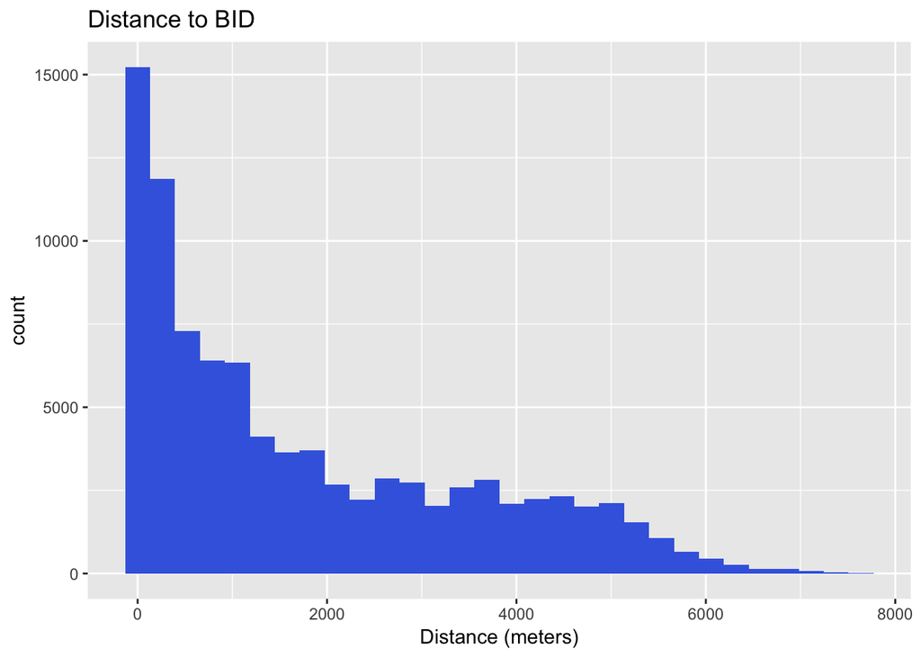

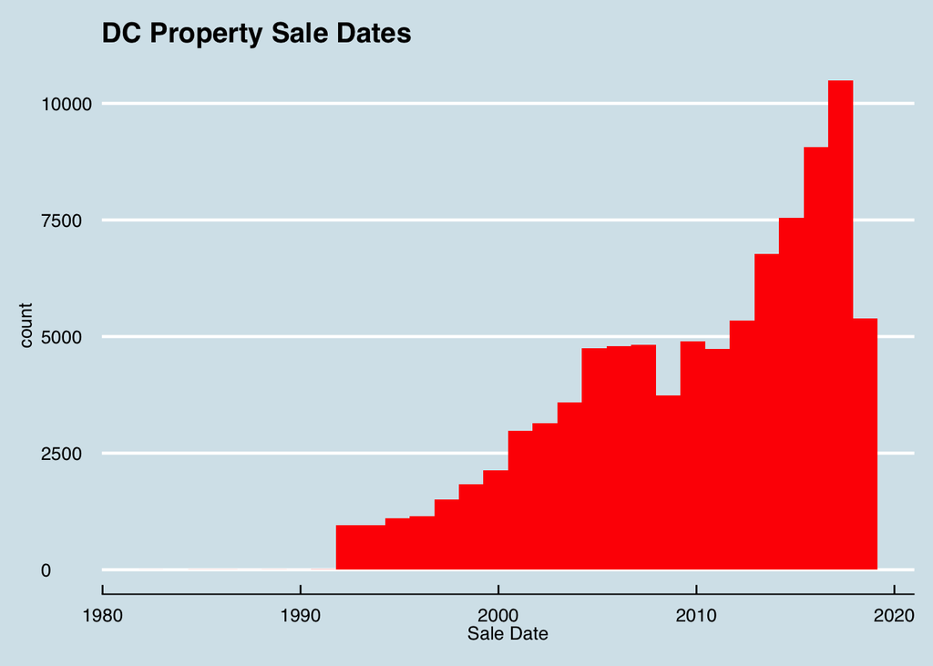

## Model

My primary base model is reproduced below

$$\hat{ln(P_i)} = \alpha + \beta_1 (I*X_1) + \beta_2 (I*X_2) + \beta_3 (I*X_3) + \beta_4 (I*X_4) + \gamma Z + \epsilon_i$$

Where my dependant variable is the natural log of price of each property i. $\alpha$ is a constant, and my first four terms are interaction terms. $\beta_i$ are the coefficients for each of the interaction terms. $I$ is a dummy variable indicating whether the property is within the boundaries of a BID. $X_1$ is a dummy variable with properties five years before the BID designation, $X_2$ is a dummy variable with properties two years before the BID designation, $X_3$ is a dummy variable with properties at the time of the BID designation, and $X_4$ is a dummy variable with properties five years after the BID designation.

### Variable additions

I created a dummy variable in my data frame to show whether the property was in a BID or not, and making the dummy variables for the interaction terms.

### Creating the Dummy Variables

I created dummy variables for any variable that was not quantitaive so I could add it to my hedonic model. I used the *dummy* package to create the variables.

```r
data_final_model_withjoin <- full_join(all_dummies,all_quantitative, by= "V1")
```

Next I removed the V1 variable (the FID) which I used to combine both tables.

```r
data_final_model <- subset(data_final_model_withjoin, select = -(V1))
data_final_model <- data.frame(data_final_model)
```

Finally, I set up my model and reproduced my results below

```r
model_BID <- lm(log(data_final_cleaning$PRICE)~.,data_final_model)

summary(model_BID)
```

```
##
## Call:
## lm(formula = log(data_final_cleaning$PRICE) ~ ., data = data_final_model)
##
## Residuals:
##      Min       1Q   Median       3Q      Max
## -13.0297  -0.1358   0.0408   0.1820   1.5084
##
## Coefficients: (33 not defined because of singularities)
##                                                                                                    Estimate
## (Intercept)                                                                                       1.051e+01
## X.Users.erickcohen.Documents.Coding.R.Projects.thesis_explore.Econ_BID_thesis.Rmd.0              -5.073e-01
## X.Users.erickcohen.Documents.Coding.R.Projects.thesis_explore.Econ_BID_thesis.Rmd.1              -4.377e-01
## X.Users.erickcohen.Documents.Coding.R.Projects.thesis_explore.Econ_BID_thesis.Rmd.2              -3.961e-01
## X.Users.erickcohen.Documents.Coding.R.Projects.thesis_explore.Econ_BID_thesis.Rmd.3                      NA
## X.Users.erickcohen.Documents.Coding.R.Projects.thesis_explore.Econ_BID_thesis.Rmd.4                      NA
## X.Users.erickcohen.Documents.Coding.R.Projects.thesis_explore.Econ_BID_thesis.Rmd.5                      NA
## X.Users.erickcohen.Documents.Coding.R.Projects.thesis_explore.Econ_BID_thesis.Rmd.7                      NA
## X.Users.erickcohen.Documents.Coding.R.Projects.thesis_explore.Econ_BID_thesis.Rmd.11                     NA
## X.Users.erickcohen.Documents.Coding.R.Projects.thesis_explore.Econ_BID_thesis.Rmd.0.1            -1.885e-01
## X.Users.erickcohen.Documents.Coding.R.Projects.thesis_explore.Econ_BID_thesis.Rmd.N              -4.459e-02
## X.Users.erickcohen.Documents.Coding.R.Projects.thesis_explore.Econ_BID_thesis.Rmd.Y                      NA
## X.Users.erickcohen.Documents.Coding.R.Projects.thesis_explore.Econ_BID_thesis.Rmd.20001           2.383e-01
## X.Users.erickcohen.Documents.Coding.R.Projects.thesis_explore.Econ_BID_thesis.Rmd.20002           1.215e-01
## X.Users.erickcohen.Documents.Coding.R.Projects.thesis_explore.Econ_BID_thesis.Rmd.20003           2.145e-01
## X.Users.erickcohen.Documents.Coding.R.Projects.thesis_explore.Econ_BID_thesis.Rmd.20004           1.614e-01
## X.Users.erickcohen.Documents.Coding.R.Projects.thesis_explore.Econ_BID_thesis.Rmd.20005           2.245e-03
## X.Users.erickcohen.Documents.Coding.R.Projects.thesis_explore.Econ_BID_thesis.Rmd.20006                  NA
## X.Users.erickcohen.Documents.Coding.R.Projects.thesis_explore.Econ_BID_thesis.Rmd.20007           1.652e-01
## X.Users.erickcohen.Documents.Coding.R.Projects.thesis_explore.Econ_BID_thesis.Rmd.20008                  NA
## X.Users.erickcohen.Documents.Coding.R.Projects.thesis_explore.Econ_BID_thesis.Rmd.20009           2.533e-01
## X.Users.erickcohen.Documents.Coding.R.Projects.thesis_explore.Econ_BID_thesis.Rmd.20010                  NA
## X.Users.erickcohen.Documents.Coding.R.Projects.thesis_explore.Econ_BID_thesis.Rmd.20011                  NA
## X.Users.erickcohen.Documents.Coding.R.Projects.thesis_explore.Econ_BID_thesis.Rmd.20012                  NA
## X.Users.erickcohen.Documents.Coding.R.Projects.thesis_explore.Econ_BID_thesis.Rmd.20015                  NA
## X.Users.erickcohen.Documents.Coding.R.Projects.thesis_explore.Econ_BID_thesis.Rmd.20016                  NA
## X.Users.erickcohen.Documents.Coding.R.Projects.thesis_explore.Econ_BID_thesis.Rmd.20017                  NA
## X.Users.erickcohen.Documents.Coding.R.Projects.thesis_explore.Econ_BID_thesis.Rmd.20018                  NA
## X.Users.erickcohen.Documents.Coding.R.Projects.thesis_explore.Econ_BID_thesis.Rmd.20019                  NA
## X.Users.erickcohen.Documents.Coding.R.Projects.thesis_explore.Econ_BID_thesis.Rmd.20020          -6.326e-01
```

[output cut: 341 more lines]

```
## STORIES_var                                                                                      ***
## KITCHENS_var                                                                                     ***
## FIREPLACES_var                                                                                   ***
## sale_date_l_var                                                                                  ***
## V9                                                                                               ***
## V10                                                                                              ***
## V11                                                                                              .
## V12                                                                                              ***
## ---
## Signif. codes:  0 '***' 0.001 '**' 0.01 '*' 0.05 '.' 0.1 ' ' 1
##
## Residual standard error: 0.3716 on 6837 degrees of freedom
##   (84814 observations deleted due to missingness)
## Multiple R-squared:  0.5566, Adjusted R-squared:  0.5539
## F-statistic: 209.3 on 41 and 6837 DF,  p-value: < 2.2e-16
```

## Testing for Spillover Effects

Next, I calculated for spillover effects

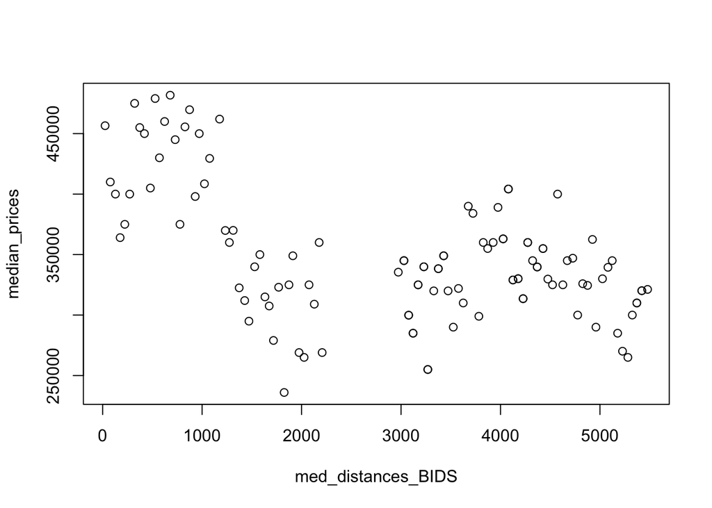

```r
data_spill_model_withjoin <- full_join(all_dummies_spill,all_quantitative_spill)
#remove V1 used to join the dfs
data_spill_model <- subset(data_spill_model_withjoin, select = -(V1))

data_spill_model <- data.frame(data_spill_model)

spillover_model <- lm(log(data_spill_model$V2)~.,data_spill_model)

summary(spillover_model)
```

```
##
## Call:
## lm(formula = log(data_spill_model$V2) ~ ., data = data_spill_model)
##
## Residuals:
##      Min       1Q   Median       3Q      Max
## -13.0714  -0.1810   0.0423   0.2482   4.9475
##
## Coefficients: (7 not defined because of singularities)
##                                                                                                    Estimate
## (Intercept)                                                                                       1.023e+01
## X.Users.erickcohen.Documents.Coding.R.Projects.thesis_explore.Econ_BID_thesis.Rmd.0              -4.314e-01
## X.Users.erickcohen.Documents.Coding.R.Projects.thesis_explore.Econ_BID_thesis.Rmd.1              -2.888e-01
## X.Users.erickcohen.Documents.Coding.R.Projects.thesis_explore.Econ_BID_thesis.Rmd.2              -2.400e-01
## X.Users.erickcohen.Documents.Coding.R.Projects.thesis_explore.Econ_BID_thesis.Rmd.3              -2.659e-01
## X.Users.erickcohen.Documents.Coding.R.Projects.thesis_explore.Econ_BID_thesis.Rmd.4              -5.665e-01
## X.Users.erickcohen.Documents.Coding.R.Projects.thesis_explore.Econ_BID_thesis.Rmd.5              -3.527e-01
## X.Users.erickcohen.Documents.Coding.R.Projects.thesis_explore.Econ_BID_thesis.Rmd.7              -6.761e-01
## X.Users.erickcohen.Documents.Coding.R.Projects.thesis_explore.Econ_BID_thesis.Rmd.11                     NA
## X.Users.erickcohen.Documents.Coding.R.Projects.thesis_explore.Econ_BID_thesis.Rmd.0.1             1.107e-02
## X.Users.erickcohen.Documents.Coding.R.Projects.thesis_explore.Econ_BID_thesis.Rmd.N              -1.001e-01
## X.Users.erickcohen.Documents.Coding.R.Projects.thesis_explore.Econ_BID_thesis.Rmd.Y                      NA
## X.Users.erickcohen.Documents.Coding.R.Projects.thesis_explore.Econ_BID_thesis.Rmd.20001          -1.104e-01
## X.Users.erickcohen.Documents.Coding.R.Projects.thesis_explore.Econ_BID_thesis.Rmd.20002          -2.980e-01
## X.Users.erickcohen.Documents.Coding.R.Projects.thesis_explore.Econ_BID_thesis.Rmd.20003          -1.775e-01
## X.Users.erickcohen.Documents.Coding.R.Projects.thesis_explore.Econ_BID_thesis.Rmd.20004           2.122e-02
## X.Users.erickcohen.Documents.Coding.R.Projects.thesis_explore.Econ_BID_thesis.Rmd.20005          -1.791e-01
## X.Users.erickcohen.Documents.Coding.R.Projects.thesis_explore.Econ_BID_thesis.Rmd.20006          -7.079e-01
## X.Users.erickcohen.Documents.Coding.R.Projects.thesis_explore.Econ_BID_thesis.Rmd.20007          -2.051e-02
## X.Users.erickcohen.Documents.Coding.R.Projects.thesis_explore.Econ_BID_thesis.Rmd.20008           2.120e-02
## X.Users.erickcohen.Documents.Coding.R.Projects.thesis_explore.Econ_BID_thesis.Rmd.20009          -2.916e-02
## X.Users.erickcohen.Documents.Coding.R.Projects.thesis_explore.Econ_BID_thesis.Rmd.20010          -2.083e-01
## X.Users.erickcohen.Documents.Coding.R.Projects.thesis_explore.Econ_BID_thesis.Rmd.20011          -3.722e-01
## X.Users.erickcohen.Documents.Coding.R.Projects.thesis_explore.Econ_BID_thesis.Rmd.20012          -3.119e-01
## X.Users.erickcohen.Documents.Coding.R.Projects.thesis_explore.Econ_BID_thesis.Rmd.20015          -3.597e-02
## X.Users.erickcohen.Documents.Coding.R.Projects.thesis_explore.Econ_BID_thesis.Rmd.20016           3.224e-02
## X.Users.erickcohen.Documents.Coding.R.Projects.thesis_explore.Econ_BID_thesis.Rmd.20017          -2.630e-01
## X.Users.erickcohen.Documents.Coding.R.Projects.thesis_explore.Econ_BID_thesis.Rmd.20018          -3.753e-01
## X.Users.erickcohen.Documents.Coding.R.Projects.thesis_explore.Econ_BID_thesis.Rmd.20019          -7.119e-01
## X.Users.erickcohen.Documents.Coding.R.Projects.thesis_explore.Econ_BID_thesis.Rmd.20020          -6.194e-01
```

[output cut: 571 more lines]

```
## V115                                                                                             ***
## BATHRM_var                                                                                       ***
## ROOMS_var                                                                                        ***
## BEDRM_var                                                                                        ***
## STORIES_var
## KITCHENS_var                                                                                     ***
## FIREPLACES_var                                                                                   .
## sale_date_l_var                                                                                  ***
## ---
## Signif. codes:  0 '***' 0.001 '**' 0.01 '*' 0.05 '.' 0.1 ' ' 1
##
## Residual standard error: 0.4433 on 91578 degrees of freedom
##   (1 observation deleted due to missingness)
## Multiple R-squared:  0.6402, Adjusted R-squared:  0.6397
## F-statistic:  1442 on 113 and 91578 DF,  p-value: < 2.2e-16
```

```r
###
```